# TIMSS 2015 in Japan. Project 2

# Factor Analysis

As I wrote earlier, factor analysis will be performed on 24 variables related to mathematics. Therefore, I create two separate datasets, in the first I leave 24 variables for EFA, the remaining 5 are still saved in a new dataset. In addition, a correlation matrix needs to be built to ensure that factor analysis makes sense.

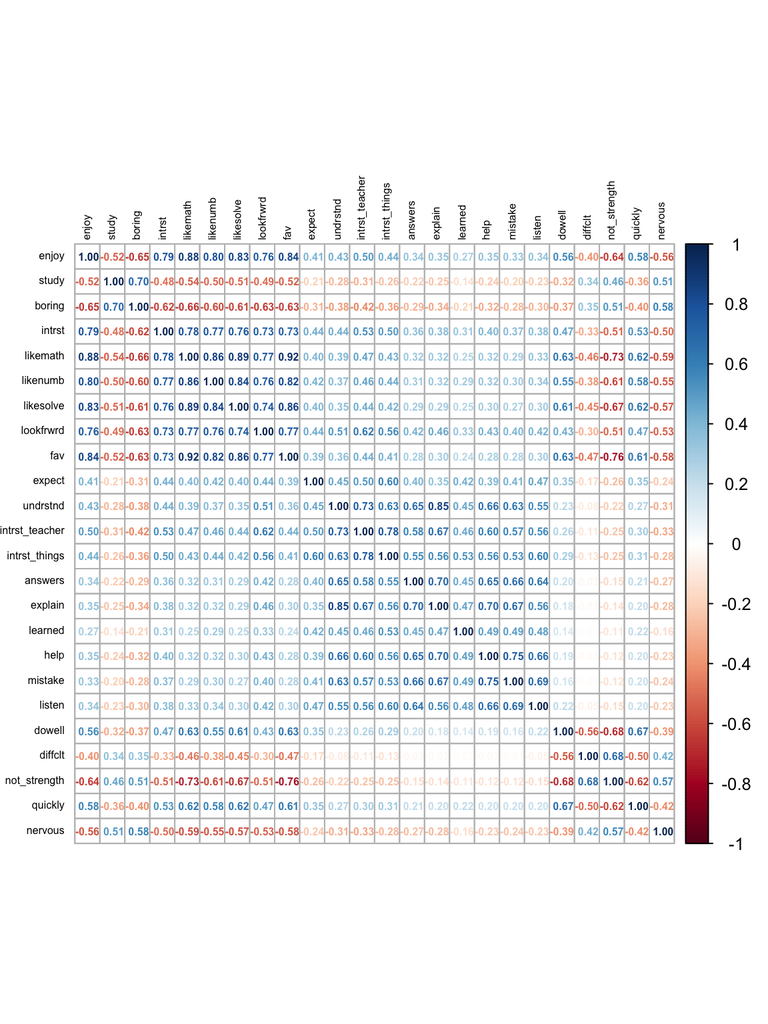

```r
data1 = data[,c(25:29)]
data = data[, c(1:24)]

corr = hetcor(data)
corrplot(corr$correlations, method="number", title = "", tl.cex = 0.5, tl.col = "black", number.cex=0.5)
```

**Interpretation:**

- All correlations that are greater than + -0.3 can be considered significant. It can be seen from the graph that there are 5 groups of variables that have fairly high correlation rates and therefore can be our potential factors.

## How many factors do we need?

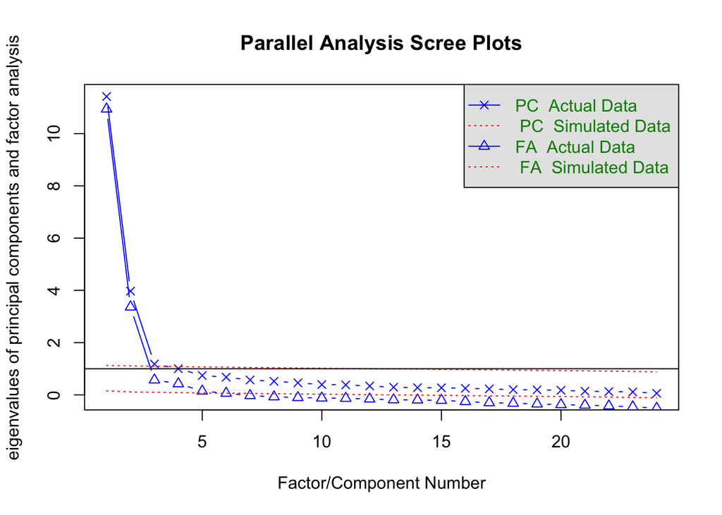

```
## Parallel analysis suggests that the number of factors =  5  and the number of components =  3
```

```r
fa.parallel(corr$correlations, 4745) # вторая цифра - кол-во данных
```

**Interpretation of the Parallel Analysis screen plot:**

- Parallel analysis suggests there are 5 latent factors
- We don’t have a single triangle on the black line, so maybe 5 factors are the best solution.
- The graph shows that 5 factors lie above the FA Simulated Data line
- the analysis offers us 3 components, since three crosses lie above the Principal Components Simulated Data line

## Building a factor model with 5 factors

In order to carry out factor analysis with categorical or factorial variables, all of them must be converted to numeric. I also create a 5-factor model using the fa () function. I decided to focus on 5 factors, since despite some poor performance relative to variables, this option turns out to be the most logical in terms of statistical characteristics, such as RMSE, Chi Square, Tucker Lewis Index.

When using “cor =” mixed “, rotate =” oblimin “is automatically enabled, but I wanted to use it anyway, since oblimin rotation, which recognizes that there is likely to be some correlation between pain relief factors in the real world.

```r
data <- data.frame(lapply(data, function(x) as.numeric(as.factor(x))))
fa_plot5 <- fa(data, nfactors=5, rotate = "oblimin", cor='mixed')
fa_plot5
```

```
## Factor Analysis using method =  minres
## Call: fa(r = data, nfactors = 5, rotate = "oblimin", cor = "mixed")
## Standardized loadings (pattern matrix) based upon correlation matrix
##                  MR1   MR2   MR3   MR5   MR4   h2    u2 com
## enjoy           0.86  0.04  0.00 -0.01 -0.06 0.83 0.170 1.0
## study          -0.16 -0.06  0.14  0.01  0.57 0.57 0.435 1.3
## boring         -0.30 -0.05  0.05 -0.06  0.60 0.75 0.252 1.5
## intrst          0.79  0.03  0.08  0.12 -0.06 0.72 0.277 1.1
## likemath        0.91  0.02 -0.09 -0.05 -0.01 0.93 0.071 1.0
## likenumb        0.92 -0.02  0.02  0.03  0.01 0.82 0.185 1.0
## likesolve       0.88 -0.02 -0.08 -0.01  0.00 0.85 0.149 1.0
## lookfrwrd       0.71  0.06  0.11  0.19 -0.15 0.75 0.247 1.3
## fav             0.82  0.00 -0.16 -0.02 -0.02 0.87 0.127 1.1
## expect          0.16  0.08 -0.12  0.51  0.13 0.45 0.549 1.5
## undrstnd       -0.05  0.65 -0.04  0.21 -0.13 0.71 0.291 1.3
## intrst_teacher  0.12  0.26  0.06  0.56 -0.11 0.73 0.269 1.6
## intrst_things   0.00  0.00 -0.04  0.93  0.00 0.88 0.117 1.0
## answers        -0.02  0.79 -0.03  0.02  0.01 0.64 0.361 1.0
## explain        -0.08  0.84  0.00  0.02 -0.12 0.74 0.258 1.1
## learned         0.07  0.36  0.02  0.29  0.11 0.38 0.622 2.2
## help            0.04  0.86  0.03 -0.04  0.02 0.71 0.286 1.0
## mistake         0.04  0.90  0.01 -0.08  0.07 0.72 0.283 1.0
## listen          0.05  0.63 -0.01  0.16  0.07 0.58 0.417 1.2
## dowell          0.20  0.07 -0.70  0.06  0.17 0.68 0.316 1.3
## diffclt         0.15  0.05  0.81 -0.04  0.14 0.59 0.411 1.1
## not_strength   -0.18  0.00  0.72  0.02  0.13 0.80 0.203 1.2
## quickly         0.29  0.04 -0.54  0.08  0.10 0.58 0.421 1.7
## nervous        -0.22 -0.12  0.27  0.04  0.37 0.51 0.493 2.8
##
##                        MR1  MR2  MR3  MR5  MR4
## SS loadings           6.23 4.43 2.56 2.23 1.35
## Proportion Var        0.26 0.18 0.11 0.09 0.06
## Cumulative Var        0.26 0.44 0.55 0.64 0.70
## Proportion Explained  0.37 0.26 0.15 0.13 0.08
## Cumulative Proportion 0.37 0.63 0.79 0.92 1.00
##
##  With factor correlations of
##       MR1   MR2   MR3   MR5   MR4
## MR1  1.00  0.42 -0.64  0.48 -0.49
## MR2  0.42  1.00 -0.10  0.71 -0.24
```

[output cut: 10 more lines]

```
## The root mean square of the residuals (RMSR) is  0.02
## The df corrected root mean square of the residuals is  0.03
##
## The harmonic number of observations is  4745 with the empirical chi square  1017.8  with prob <  2.1e-122
## The total number of observations was  4745  with Likelihood Chi Square =  5535.02  with prob <  0
##
## Tucker Lewis Index of factoring reliability =  0.915
## RMSEA index =  0.083  and the 90 % confidence intervals are  0.081 0.084
## BIC =  4129.86
## Fit based upon off diagonal values = 1
## Measures of factor score adequacy
##                                                    MR1  MR2  MR3  MR5  MR4
## Correlation of (regression) scores with factors   0.99 0.97 0.94 0.96 0.88
## Multiple R square of scores with factors          0.97 0.93 0.88 0.92 0.77
## Minimum correlation of possible factor scores     0.95 0.87 0.77 0.83 0.54
```

**Interpretation of the Factor Analysis:**

Now let’s look at the graph.

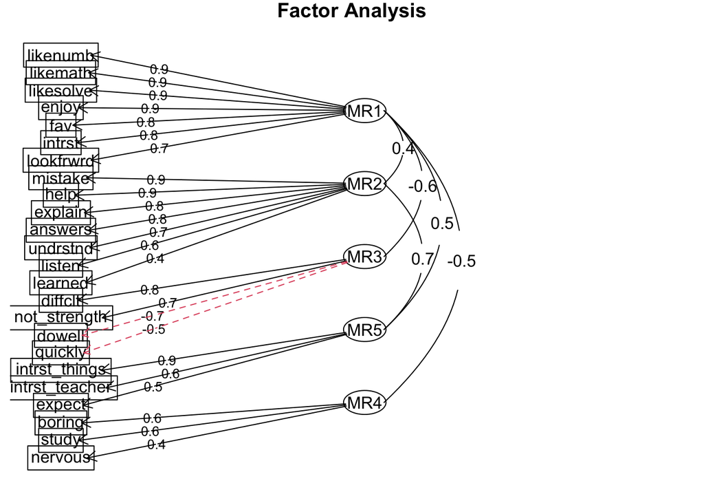

```r
fa.diagram(fa_plot5)
```

```r
Factor <- c("MR1" , "MR2" , "MR3" , "MR4" , "MR5")

Variables <- c("likenumb, likemath, likesolve, enjoy, fav, intrst, lookfrwrd" , "mistake, help, explain, answers, undrstnd, listen, learned" , "diffclt, not_strength, dowell, quickly" , "boring, study, nervous", "intrst_teacher, intrst_things, expect")


Explanation <- c("The factor is responsible for the student's love of maths, whether he or she likes it. The higher the values assigned to a particular individual in the future, the more he or she likes doing mathematics." , "The factor is responsible for students' interaction with the teacher during mathematics lessons." , "The factor is responsible for how easy maths is for the student." , "The factor is responsible for the student not liking mathematics and feeling uncomfortable doing it." , "The factor is responsible for the student's attitude towards what the teacher says in class.")

tab <- data.frame(Factor, Variables, Explanation)

tab %>% datatable(options = list(scrollX='400px', scrollY='270px'))
```

|  | Factor | Variables | Explanation |
| --- | --- | --- | --- |
| 1 | MR1 | likenumb, likemath, likesolve, enjoy, fav, intrst, lookfrwrd | The factor is responsible for the student's love of maths, whether he or she likes it. The higher the values assigned to a particular individual in the future, the more he or she likes doing mathemati… |
| 2 | MR2 | mistake, help, explain, answers, undrstnd, listen, learned | The factor is responsible for students' interaction with the teacher during mathematics lessons. |
| 3 | MR3 | diffclt, not_strength, dowell, quickly | The factor is responsible for how easy maths is for the student. |
| 4 | MR4 | boring, study, nervous | The factor is responsible for the student not liking mathematics and feeling uncomfortable doing it. |
| 5 | MR5 | intrst_teacher, intrst_things, expect | The factor is responsible for the student's attitude towards what the teacher says in class. |

**Interpretation of the Factor Analysis:**

## Chronbach’s alpha

Chronbach’s alpha is a consistency test that measures how closely a set of elements are related as a group. For each scale (factor) it is necessary to carry out separately. Check.keys = T - Expands all arguments in one direction. For the matrix to be only +, it is therefore important to include it if any questions were “expanded”. In our case, this situation may be typical for the third factor. However, all factors need to be checked for consistency. Chronbach’s alpha must be at least 0.7, otherwise it means that all questions on the scale measure the same concept.

### MR1

```r
# MR1
psych::alpha(data[,c("likenumb", "likemath", "likesolve", "enjoy", "fav", "intrst", "lookfrwrd")], check.keys = T)
```

```
##
## Reliability analysis
## Call: psych::alpha(x = data[, c("likenumb", "likemath", "likesolve",
##     "enjoy", "fav", "intrst", "lookfrwrd")], check.keys = T)
##
##   raw_alpha std.alpha G6(smc) average_r S/N    ase mean   sd median_r
##       0.95      0.95    0.94      0.72  18 0.0011  2.7 0.78      0.7
##
##  lower alpha upper     95% confidence boundaries
## 0.94 0.95 0.95
##
##  Reliability if an item is dropped:
##           raw_alpha std.alpha G6(smc) average_r S/N alpha se  var.r med.r
## likenumb       0.94      0.94    0.93      0.72  16   0.0013 0.0045  0.70
## likemath       0.93      0.93    0.92      0.70  14   0.0015 0.0018  0.68
## likesolve      0.94      0.94    0.93      0.71  15   0.0014 0.0035  0.69
## enjoy          0.94      0.94    0.93      0.72  15   0.0014 0.0041  0.69
## fav            0.94      0.94    0.93      0.71  15   0.0014 0.0028  0.69
## intrst         0.94      0.94    0.94      0.74  17   0.0012 0.0035  0.75
## lookfrwrd      0.94      0.94    0.94      0.74  17   0.0012 0.0035  0.75
##
##  Item statistics
##              n raw.r std.r r.cor r.drop mean   sd
## likenumb  4745  0.86  0.86  0.83   0.81  2.9 0.78
## likemath  4745  0.93  0.92  0.92   0.89  2.6 0.97
## likesolve 4745  0.89  0.89  0.87   0.85  2.6 0.93
## enjoy     4745  0.88  0.88  0.86   0.84  2.5 0.91
## fav       4745  0.90  0.89  0.88   0.85  2.8 0.99
## intrst    4745  0.82  0.83  0.78   0.76  2.5 0.85
## lookfrwrd 4745  0.82  0.82  0.78   0.76  2.9 0.85
##
## Non missing response frequency for each item
##              1    2    3    4 miss
## likenumb  0.06 0.19 0.54 0.21    0
## likemath  0.15 0.28 0.37 0.20    0
## likesolve 0.12 0.30 0.39 0.19    0
## enjoy     0.16 0.37 0.34 0.13    0
## fav       0.13 0.20 0.38 0.29    0
## intrst    0.12 0.34 0.43 0.12    0
## lookfrwrd 0.07 0.23 0.47 0.23    0
```

**Interpretation:**

### MR2

```r
# MR2
psych::alpha(data[,c("mistake", "help", "explain", "answers", "undrstnd", "listen", "learned")], check.keys = T)
```

```
##
## Reliability analysis
## Call: psych::alpha(x = data[, c("mistake", "help", "explain", "answers",
##     "undrstnd", "listen", "learned")], check.keys = T)
##
##   raw_alpha std.alpha G6(smc) average_r S/N    ase mean   sd median_r
##       0.89      0.89    0.89      0.53   8 0.0025  2.2 0.62     0.57
##
##  lower alpha upper     95% confidence boundaries
## 0.88 0.89 0.89
##
##  Reliability if an item is dropped:
##          raw_alpha std.alpha G6(smc) average_r S/N alpha se  var.r med.r
## mistake       0.87      0.87    0.86      0.52 6.5   0.0030 0.0122  0.56
## help          0.87      0.87    0.86      0.52 6.5   0.0030 0.0121  0.55
## explain       0.86      0.86    0.85      0.52 6.4   0.0031 0.0082  0.56
## answers       0.87      0.87    0.87      0.53 6.7   0.0029 0.0128  0.55
## undrstnd      0.87      0.87    0.85      0.53 6.6   0.0030 0.0091  0.57
## listen        0.87      0.88    0.87      0.54 7.0   0.0028 0.0134  0.57
## learned       0.89      0.89    0.89      0.59 8.5   0.0024 0.0050  0.58
##
##  Item statistics
##             n raw.r std.r r.cor r.drop mean   sd
## mistake  4745  0.81  0.81  0.78   0.73  2.1 0.78
## help     4745  0.81  0.81  0.78   0.73  2.0 0.76
## explain  4745  0.83  0.83  0.81   0.75  2.1 0.84
## answers  4745  0.79  0.79  0.74   0.70  2.1 0.78
## undrstnd 4745  0.80  0.80  0.77   0.71  2.2 0.82
## listen   4745  0.76  0.76  0.70   0.66  2.3 0.82
## learned  4745  0.63  0.63  0.52   0.50  2.7 0.81
##
## Non missing response frequency for each item
##             1    2    3    4 miss
## mistake  0.22 0.54 0.19 0.05    0
## help     0.23 0.56 0.16 0.05    0
## explain  0.24 0.50 0.19 0.07    0
## answers  0.22 0.55 0.18 0.05    0
## undrstnd 0.20 0.52 0.21 0.08    0
## listen   0.16 0.50 0.26 0.08    0
## learned  0.07 0.32 0.46 0.15    0
```

**Interpretation:**

- Cronbach’s alpha is 0.8889813, which indicates very good scale reliability. This means that the variables used have common covariance and are likely to measure the same underlying concept.

### MR3

```r
# MR3
psych::alpha(data[,c("diffclt", "not_strength", "dowell", "quickly")], check.keys = T)
```

```
##
## Reliability analysis
## Call: psych::alpha(x = data[, c("diffclt", "not_strength", "dowell",
##     "quickly")], check.keys = T)
##
##   raw_alpha std.alpha G6(smc) average_r S/N    ase mean   sd median_r
##       0.82      0.82    0.79      0.54 4.7 0.0041  2.3 0.72     0.56
##
##  lower alpha upper     95% confidence boundaries
## 0.81 0.82 0.83
##
##  Reliability if an item is dropped:
##              raw_alpha std.alpha G6(smc) average_r S/N alpha se  var.r med.r
## diffclt           0.79      0.80    0.73      0.57 4.0   0.0051 0.0011  0.58
## not_strength      0.75      0.75    0.68      0.50 3.1   0.0063 0.0052  0.49
## dowell-           0.77      0.77    0.69      0.52 3.3   0.0057 0.0058  0.54
## quickly-          0.79      0.79    0.72      0.56 3.8   0.0051 0.0039  0.59
##
##  Item statistics
##                 n raw.r std.r r.cor r.drop mean   sd
## diffclt      4745  0.79  0.78  0.67   0.61  2.5 0.90
## not_strength 4745  0.86  0.84  0.78   0.71  2.2 1.03
## dowell-      4745  0.81  0.82  0.75   0.67  2.1 0.83
## quickly-     4745  0.77  0.79  0.68   0.62  2.3 0.79
##
## Non missing response frequency for each item
##                 1    2    3    4 miss
## diffclt      0.16 0.32 0.40 0.12    0
## not_strength 0.32 0.29 0.26 0.13    0
## dowell       0.06 0.21 0.48 0.25    0
## quickly      0.07 0.27 0.51 0.14    0
```

**Interpretation:**

- Cronbach’s alpha is 0.8243822, which indicates very good scale reliability. This means that the variables used have common covariance and are likely to measure the same underlying concept.

### MR4

```r
# MR4
psych::alpha(data[,c("boring", "study", "nervous")], check.keys = T)
```

```
##
## Reliability analysis
## Call: psych::alpha(x = data[, c("boring", "study", "nervous")], check.keys = T)
##
##   raw_alpha std.alpha G6(smc) average_r S/N    ase mean   sd median_r
##       0.77      0.77     0.7      0.52 3.3 0.0059  2.7 0.74     0.51
##
##  lower alpha upper     95% confidence boundaries
## 0.75 0.77 0.78
##
##  Reliability if an item is dropped:
##         raw_alpha std.alpha G6(smc) average_r S/N alpha se var.r med.r
## boring       0.61      0.61    0.44      0.44 1.6   0.0112    NA  0.44
## study        0.67      0.68    0.51      0.51 2.1   0.0094    NA  0.51
## nervous      0.76      0.77    0.62      0.62 3.3   0.0068    NA  0.62
##
##  Item statistics
##            n raw.r std.r r.cor r.drop mean   sd
## boring  4745  0.85  0.86  0.76   0.67  2.7 0.86
## study   4745  0.84  0.83  0.71   0.61  2.7 0.93
## nervous 4745  0.79  0.79  0.60   0.53  2.8 0.92
##
## Non missing response frequency for each item
##            1    2    3    4 miss
## boring  0.11 0.27 0.47 0.15    0
## study   0.12 0.25 0.42 0.20    0
## nervous 0.11 0.23 0.44 0.22    0
```

**Interpretation:**

- Cronbach’s alpha is 0.7680854, which indicates good scale reliability. This means that the variables used have common covariance and are likely to measure the same underlying concept.

### MR5

```r
# MR5
psych::alpha(data[,c("intrst_teacher", "intrst_things", "expect")], check.keys = T)
```

```
##
## Reliability analysis
## Call: psych::alpha(x = data[, c("intrst_teacher", "intrst_things",
##     "expect")], check.keys = T)
##
##   raw_alpha std.alpha G6(smc) average_r S/N    ase mean   sd median_r
##       0.78      0.78    0.72      0.54 3.5 0.0056  2.7 0.68     0.51
##
##  lower alpha upper     95% confidence boundaries
## 0.77 0.78 0.79
##
##  Reliability if an item is dropped:
##                raw_alpha std.alpha G6(smc) average_r S/N alpha se var.r med.r
## intrst_teacher      0.68      0.68    0.51      0.51 2.1   0.0093    NA  0.51
## intrst_things       0.60      0.60    0.43      0.43 1.5   0.0117    NA  0.43
## expect              0.81      0.81    0.68      0.68 4.3   0.0055    NA  0.68
##
##  Item statistics
##                   n raw.r std.r r.cor r.drop mean   sd
## intrst_teacher 4745  0.86  0.84  0.75   0.64  2.5 0.87
## intrst_things  4745  0.88  0.88  0.81   0.71  2.8 0.78
## expect         4745  0.77  0.78  0.57   0.51  2.8 0.79
##
## Non missing response frequency for each item
##                   1    2    3    4 miss
## intrst_teacher 0.14 0.38 0.36 0.12    0
## intrst_things  0.05 0.25 0.53 0.17    0
## expect         0.05 0.25 0.51 0.20    0
```

**Interpretation:**

- Cronbach’s alpha is 0.7800495, which indicates good scale reliability. This means that the variables used have common covariance and are likely to measure the same underlying concept.

Thus, it can be concluded that all 5 factors are reliable and all the variables assigned to them should be kept as they are now.

# Regression Analysis

## Prepearing data

```r
fascores<-fa(data, nfactors=5, rotate = "oblimin", cor='mixed', scores = T)
fascores = fascores$scores
data1 <- cbind(data1,fascores)
data1 = data1 %>% rename( factor_like_math = MR1, factor_teacher = MR2, factor_hard_math = MR3, factor_uncomfotable_math = MR4,factor_inrst_teacher = MR5)
```

## Choosing the best model

```r
library(car)
m1 = lm(success ~ sex, data = data1)
m2 = lm(success ~ sex + mother + father, data = data1)
m3 = lm(success ~ sex + mother + father + country, data = data1)
m4 = lm(success ~ sex + mother + father + country + factor_like_math, data = data1)
m5 = lm(success ~ sex + mother + father + country + factor_like_math + factor_teacher, data = data1)
m6 = lm(success ~ sex + mother + father + country + factor_like_math + factor_teacher + factor_hard_math, data = data1)
m7 = lm(success ~ sex + mother + father + country + factor_like_math + factor_teacher + factor_hard_math + factor_uncomfotable_math, data = data1)
m8 = lm(success ~ sex + mother + father + country + factor_like_math + factor_teacher + factor_hard_math + factor_uncomfotable_math + factor_inrst_teacher, data = data1)

anova(m1, m2, m3, m4, m5, m6, m7, m8)
```

```
## Analysis of Variance Table
##
## Model 1: success ~ sex
## Model 2: success ~ sex + mother + father
## Model 3: success ~ sex + mother + father + country
## Model 4: success ~ sex + mother + father + country + factor_like_math
## Model 5: success ~ sex + mother + father + country + factor_like_math +
##     factor_teacher
## Model 6: success ~ sex + mother + father + country + factor_like_math +
##     factor_teacher + factor_hard_math
## Model 7: success ~ sex + mother + father + country + factor_like_math +
##     factor_teacher + factor_hard_math + factor_uncomfotable_math
## Model 8: success ~ sex + mother + father + country + factor_like_math +
##     factor_teacher + factor_hard_math + factor_uncomfotable_math +
##     factor_inrst_teacher
##   Res.Df      RSS Df Sum of Sq         F    Pr(>F)
## 1   4743 37048617
## 2   4729 31003897 14   6044720   87.6032 < 2.2e-16 ***
## 3   4728 31003267  1       631    0.1279  0.720595
## 4   4727 26065195  1   4938071 1001.9115 < 2.2e-16 ***
## 5   4726 26027368  1     37828    7.6750  0.005621 **
## 6   4725 23757296  1   2270072  460.5869 < 2.2e-16 ***
## 7   4724 23278778  1    478518   97.0891 < 2.2e-16 ***
## 8   4723 23278014  1       764    0.1550  0.693782
## ---
## Signif. codes:  0 '***' 0.001 '**' 0.01 '*' 0.05 '.' 0.1 ' ' 1
```

**Interpretation:**

- Several models turned out to be significant: m2, m4, m5, m6 and m7. In statistics, AIC is most often used for model selection. By calculating and comparing the AIC scores of several possible models, you can choose the one that best fits the data.

```r
# install.packages("AICcmodavg")
library(AICcmodavg)
aictab(cand.set = list(m2, m4, m5, m6, m7))
```

```
##
## Model selection based on AICc:
##
##       K     AICc Delta_AICc AICcWt Cum.Wt        LL
## Mod5 22 53833.93       0.00      1      1 -26894.86
## Mod4 21 53928.46      94.53      0      1 -26943.13
## Mod3 20 54359.46     525.54      0      1 -27159.64
## Mod2 19 54364.34     530.41      0      1 -27163.09
## Mod1 17 55183.62    1349.69      0      1 -27574.75
```

**Interpretation:**